We aim to study on data about electricity consumption in Turkey from the beginning of 2016 to May 20th, 2021. We analyze the time series and built an ARIMA model using suitable AR and MA models. Then, we will predict new consumption data and check the error.

Required libraries

```r
library(ggplot2)
library(fpp)
library(data.table)
library(readxl)
library(forecast)
library(lubridate)
require(urca)
```

I changed the csv file to excel file that have date and time variables in one column.

```r
data = read_excel("/Users/demir/Desktop/data.xlsx")
data = as.data.table(data)
is.data.table(data)
```

```
## [1] TRUE
```

```r
head(data)
```

```
##                   date     cons
## 1: 2016-01-01 00:00:00 26277.24
## 2: 2016-01-01 01:00:00 24991.82
## 3: 2016-01-01 02:00:00 23532.61
## 4: 2016-01-01 03:00:00 22464.78
## 5: 2016-01-01 04:00:00 22002.91
## 6: 2016-01-01 05:00:00 21957.08
```

```r
data$cons=as.numeric(data$cons)
cons=data$cons

summary(data)
```

```
##       date                          cons
##  Min.   :2016-01-01 00:00:00   Min.   :    0
##  1st Qu.:2017-05-06 17:45:00   1st Qu.:29057
##  Median :2018-09-10 11:30:00   Median :33106
##  Mean   :2018-09-10 11:30:00   Mean   :33011
##  3rd Qu.:2020-01-15 05:15:00   3rd Qu.:36684
##  Max.   :2021-05-20 23:00:00   Max.   :49342
```

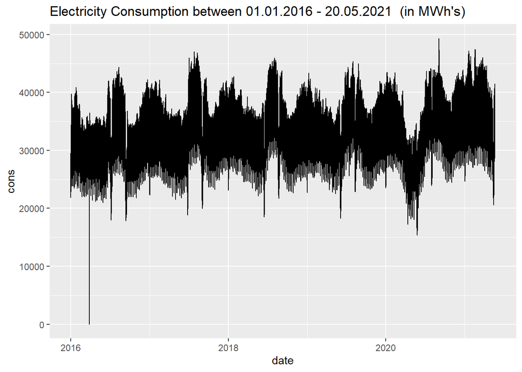

```r
ggplot(data, aes(x=date,y=cons)) + geom_line() +
  labs(title = "Electricity Consumption between 01.01.2016 - 20.05.2021  (in MWh's)")
```

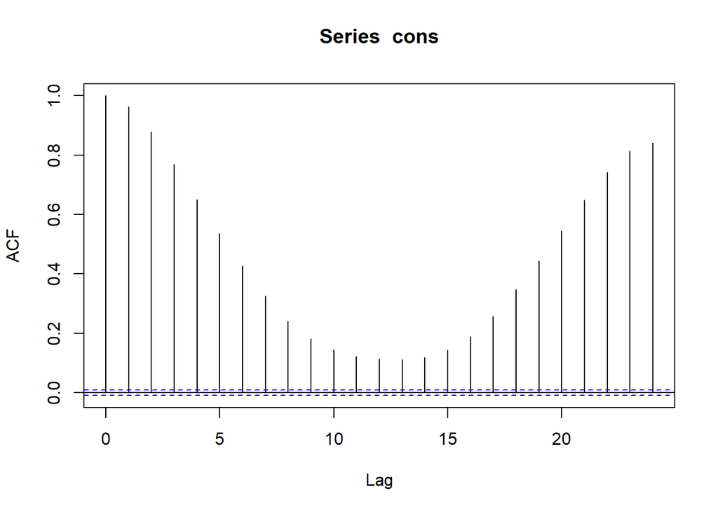

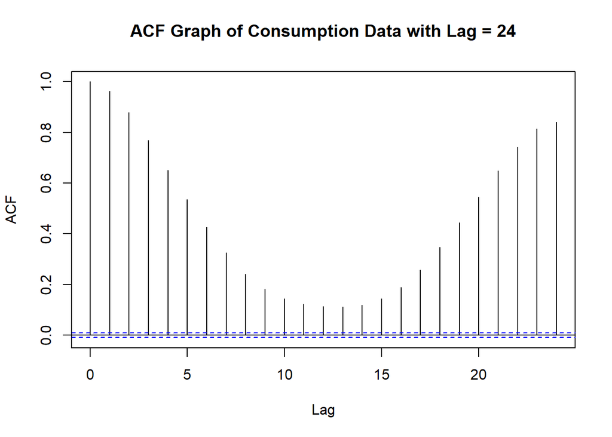

```r
plot(acf(cons, lag.max = 24), main = " ACF Graph of Consumption Data with Lag = 24 ")
```